# Task 3-internship

```python
import seaborn as sns
import matplotlib.pyplot as plt
import pandas as pd
import numpy as np

import warnings
warnings.filterwarnings(
    "ignore",
    message=".*use_inf_as_na option is deprecated.*",
    category=FutureWarning,
)

%matplotlib inline
```

```python
feedback = pd.read_csv(r"C:\Users\MASAI\OneDrive\Desktop\NMS-EXCEL\INTERNSHIP\Task 3\student_feedback.csv")
feedback.head()
```

|  | Unnamed: 0 | Student ID | Well versed with the subject | Explains concepts in an understandable way | Use of presentations | Degree of difficulty of assignments | Solves doubts willingly | Structuring of the course | Provides support for students going above and beyond | Course recommendation based on relevance |
| --- | --- | --- | --- | --- | --- | --- | --- | --- | --- | --- |
| 0 | 0 | 340 | 5 | 2 | 7 | 6 | 9 | 2 | 1 | 8 |
| 1 | 1 | 253 | 6 | 5 | 8 | 6 | 2 | 1 | 2 | 9 |
| 2 | 2 | 680 | 7 | 7 | 6 | 5 | 4 | 2 | 3 | 1 |
| 3 | 3 | 806 | 9 | 6 | 7 | 1 | 5 | 9 | 4 | 6 |
| 4 | 4 | 632 | 8 | 10 | 8 | 4 | 6 | 6 | 9 | 9 |

```python
#check for missing values
feedback.isnull().sum()
```

```
Unnamed: 0                                              0
Student ID                                              0
Well versed with the subject                            0
Explains concepts in an understandable way              0
Use of presentations                                    0
Degree of difficulty of assignments                     0
Solves doubts willingly                                 0
Structuring of the course                               0
Provides support for students going above and beyond    0
Course recommendation based on relevance                0
dtype: int64
```

```python
#Check for duplicates
feedback.duplicated().sum()
```

```
0
```

```python
#Check for unique values
feedback.nunique()
```

```
Unnamed: 0                                              1001
Student ID                                              1001
Well versed with the subject                               6
Explains concepts in an understandable way                 9
Use of presentations                                       5
Degree of difficulty of assignments                       10
Solves doubts willingly                                   10
Structuring of the course                                 10
Provides support for students going above and beyond      10
Course recommendation based on relevance                  10
dtype: int64
```

```python
#Describe the statistics of the dataset
feedback.describe()
```

|  | Unnamed: 0 | Student ID | Well versed with the subject | Explains concepts in an understandable way | Use of presentations | Degree of difficulty of assignments | Solves doubts willingly | Structuring of the course | Provides support for students going above and beyond | Course recommendation based on relevance |
| --- | --- | --- | --- | --- | --- | --- | --- | --- | --- | --- |
| count | 1001.000000 | 1001.000000 | 1001.000000 | 1001.000000 | 1001.000000 | 1001.000000 | 1001.000000 | 1001.000000 | 1001.000000 | 1001.000000 |
| mean | 500.000000 | 500.000000 | 7.497502 | 6.081918 | 5.942058 | 5.430569 | 5.474525 | 5.636364 | 5.662338 | 5.598402 |
| std | 289.108111 | 289.108111 | 1.692998 | 2.597168 | 1.415853 | 2.869046 | 2.874648 | 2.920212 | 2.891690 | 2.886617 |
| min | 0.000000 | 0.000000 | 5.000000 | 2.000000 | 4.000000 | 1.000000 | 1.000000 | 1.000000 | 1.000000 | 1.000000 |
| 25% | 250.000000 | 250.000000 | 6.000000 | 4.000000 | 5.000000 | 3.000000 | 3.000000 | 3.000000 | 3.000000 | 3.000000 |
| 50% | 500.000000 | 500.000000 | 8.000000 | 6.000000 | 6.000000 | 5.000000 | 6.000000 | 6.000000 | 6.000000 | 6.000000 |
| 75% | 750.000000 | 750.000000 | 9.000000 | 8.000000 | 7.000000 | 8.000000 | 8.000000 | 8.000000 | 8.000000 | 8.000000 |
| max | 1000.000000 | 1000.000000 | 10.000000 | 10.000000 | 8.000000 | 10.000000 | 10.000000 | 10.000000 | 10.000000 | 10.000000 |

```python
#check the dataset information
feedback.info()
```

```
<class 'pandas.core.frame.DataFrame'>
RangeIndex: 1001 entries, 0 to 1000
Data columns (total 10 columns):
 #   Column                                                Non-Null Count  Dtype
---  ------                                                --------------  -----
 0   Unnamed: 0                                            1001 non-null   int64
 1   Student ID                                            1001 non-null   int64
 2   Well versed with the subject                          1001 non-null   int64
 3   Explains concepts in an understandable way            1001 non-null   int64
 4   Use of presentations                                  1001 non-null   int64
 5   Degree of difficulty of assignments                   1001 non-null   int64
 6   Solves doubts willingly                               1001 non-null   int64
 7   Structuring of the course                             1001 non-null   int64
 8   Provides support for students going above and beyond  1001 non-null   int64
 9   Course recommendation based on relevance              1001 non-null   int64
dtypes: int64(10)
memory usage: 78.3 KB
```

```python
#Check the columns
feedback.columns
```

```
Index(['Unnamed: 0', 'Student ID', 'Well versed with the subject',
       'Explains concepts in an understandable way', 'Use of presentations',
       'Degree of difficulty of assignments', 'Solves doubts willingly',
       'Structuring of the course',
       'Provides support for students going above and beyond',
       'Course recommendation based on relevance'],
      dtype='object')
```

# Determine the insights from the dtaset

1. How well versed with the subjects were the teachers?

```
Average: 7.497502497502498
```

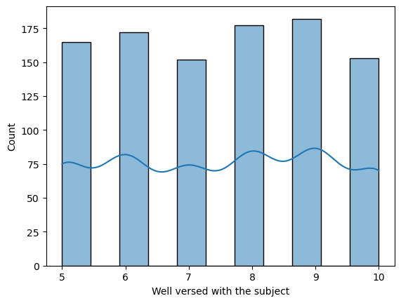

```python
# Calculate the average of a column
average = feedback['Well versed with the subject'].mean()

print("Average:", average)

#show the distribution of the students' feedback based on how well-versed the teachers were
sns.histplot(feedback['Well versed with the subject'], kde = True)
plt.show()
```

The verage feedback by the students stands at approximately 7.5. This provides that the teachers' level of awareness of the subjects they teach is quite impressive. This shows a uniform distribution since al the ratings are between 5 and 10, with a KDE overlay that shows no strong skew

# 2. Did the teachers explain the concepts in an understandable way?

```
Average: 6.081918081918082
```

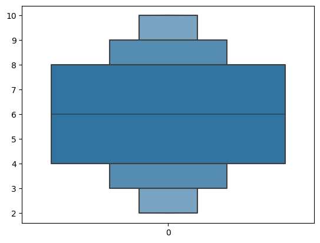

```python
# Calculate the average of a column
average = feedback['Explains concepts in an understandable way'].mean()

print("Average:", average)

sns.boxenplot(feedback['Explains concepts in an understandable way'])
plt.show()
```

The average student feedback provides that the level with which the teachers understandably delivered their content is at 6.082, which is slightly above the average of 5.

The boxen plot, however, suggests a broadly distributed perception without any clear consensus towards any extreme. Nontheless, wit most responses falling between 4 and 8, we can conclude that the teachers explained the conenpts in an understandable way.

# 3. Did the teachers use presentations in their delivery?

```
Average: 5.942057942057942
```

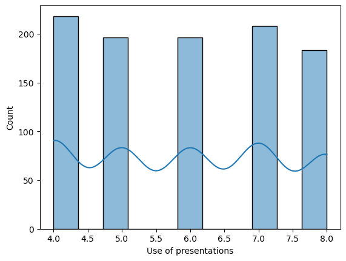

```python
# Calculate the average of a column
average = feedback['Use of presentations'].mean()

print("Average:", average)

sns.histplot(feedback['Use of presentations'], kde = True)
plt.show()
```

The average student feedback is slightly above average, at 5.94, showing that the teachers did actually use the presentations.

The Histogram shows that the student counts based on their responses were significant numbers, all above 150.

Additionally, the kde curve suggests as multi-modal distribution with no strong central tendency. This shows that there were various levels of frequency regarding the use of presentations.

# 4. What was the degree of difficulty of the assignments issued by the teachers?

```
Average: 5.430569430569431
```

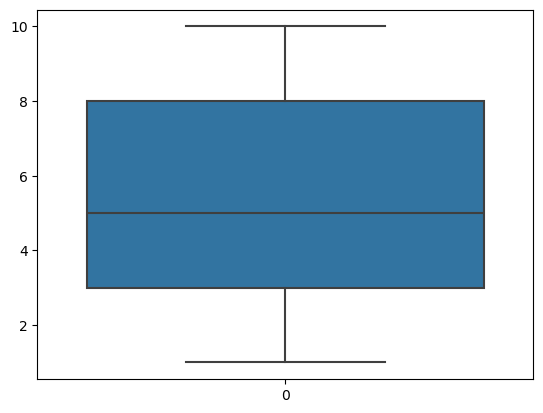

```python
# Calculate the average of a column
average = feedback['Degree of difficulty of assignments'].mean()

print("Average:", average)

sns.boxplot(feedback['Degree of difficulty of assignments'])
plt.show()
```

# 5. Did the teachers help in solving out doubts willingly?

```
Average: 5.474525474525475
```

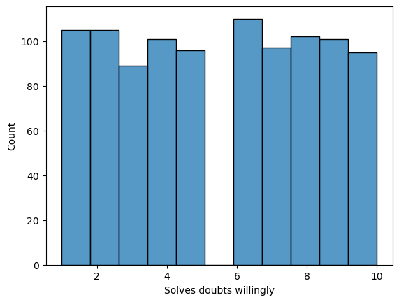

```python
# Calculate the average of a column
average = feedback['Solves doubts willingly'].mean()

print("Average:", average)

sns.histplot(feedback['Solves doubts willingly'])
plt.show()
```

Despite the average feedback being 5.47, slightly above the average of 5, the histogram shows a split in opinion of the feedback received from the students.

One of the groups gave a low rating to whether the teachers helped in solving doubts willfully, with the peak being between 1 and 3, while another group gave positive feedback for the same with the peak being between 5 and 7..

# 6. How was the structuring of the course?

```
Average: 5.636363636363637
```

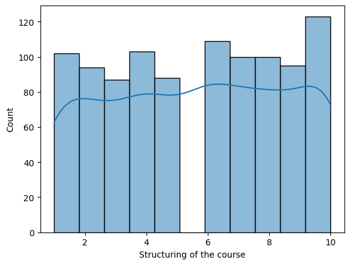

```python
# Calculate the average of a column
average = feedback['Structuring of the course'].mean()

print("Average:", average)

sns.histplot(feedback['Structuring of the course'], kde = True)
plt.show()
```

Despite the average response being 5.64, a good number of students found that the structuring of their course was poor, while another group found it to be good. This is represented by the 2 peaks.

# 7. Did the teachers Provide support for students going above and beyond?

```
Average: 5.662337662337662
```

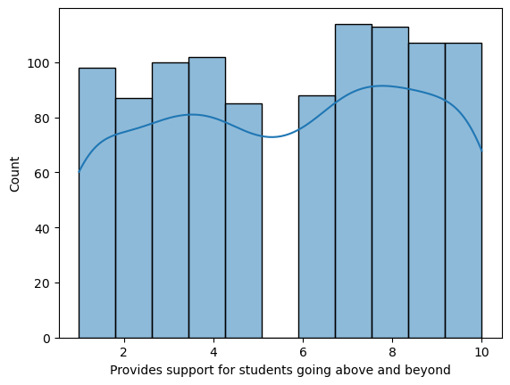

```python
# Calculate the average of a column
average = feedback['Provides support for students going above and beyond'].mean()

print("Average:", average)

sns.histplot(feedback['Provides support for students going above and beyond'], kde = True)
plt.show()
```

The average feedback is at 5.66, and despite this, the response shows a difference in opinions, with one group giving a lower rating to whether support was provided to students going above and beyond, while anoter group giving higher ratings to the same.

# 8. How relevant was your course?

```
Average: 5.5984015984015985
```

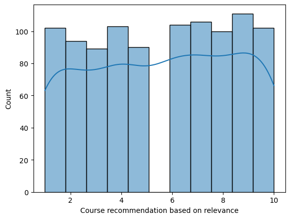

```python
# Calculate the average of a column
average = feedback['Course recommendation based on relevance'].mean()

print("Average:", average)

sns.histplot(feedback['Course recommendation based on relevance'], kde = True)
plt.show()
```

The average of 5.598 suggests that the students' courses were moderately relevant, which is slightly above an average of 5. The multi-modal distribution of the feedback indicates that there is no single dominant opinion regarding the course relevance.

With the extremes at both ends, the lower side at 1 and the higher side at 9, it shows a higher factor of polarization, with some finding the courses irrelevant (at 1) while others finding it to be relevant (at 10).

With the average rating at 5.6, the histogram shows that the courses were perceived differently by various students. A good number gave a rating of between 6-9, finding their courses to being very relevant, while another portion of students found their courses to being irrelevant, and thus giving a rating of between 1 and 4. This therefore call for re-evaluation of this aspect.

# Correlation Matrix

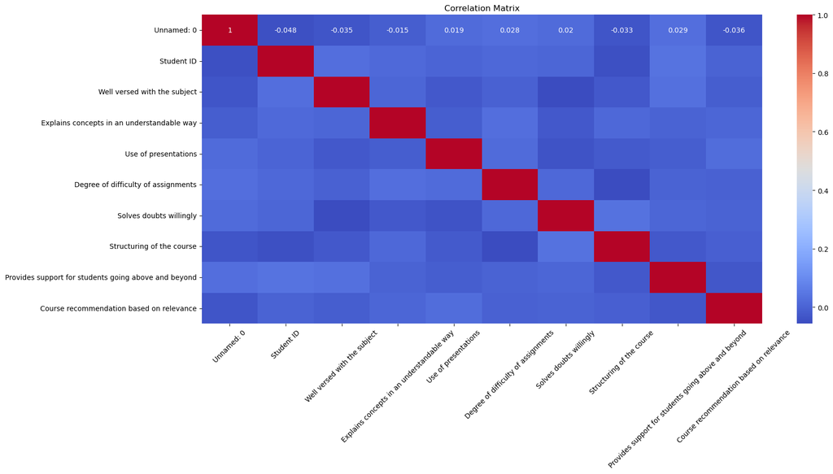

```python
plt.figure(figsize=(18, 8))
sns.heatmap(feedback.corr(), annot=True, cmap='coolwarm')
plt.title("Correlation Matrix")
plt.xticks(rotation=45)
plt.show()
```

```python
# correlation coefficient

feedback['Course recommendation based on relevance'].corr(feedback['Provides support for students going above and beyond'])
```

```
-0.031117048967270806
```